# Visualizing simulator data

Martijn Tennekes

2020-09-18

The simulator software is a framework to run mobile network data micro-simulations [1]. In this vignette, we describe how the results can be plotted with the R package **mobvis**. The package can be loaded in the standard way.

```r
library(mobvis)
```

In this vignette, we will also use **tmap** [2] to explore spatial objects in general. In the following code chunk, the **tmap** package is loaded, and via a global tmap option, warnings raised by **tmap** are suppress for plotting fictional spatial objects, i.e. that do not have a real geographic location. For this vignette, the github development version is required. This can be installed via `remotes::install_github("mtenneks/tmap")`.

```r
library(tmap)
tmap_options(show.warnings = FALSE)
```

## Example data from the simulator

Example data for the simulator, both the input and the output files, are contained in this package as a single zip file. It can be retrieved and extracted as follows.

```r
# specify folder for the simulator files
dir <- "simdata"
if (!dir.exists(dir)) dir.create(dir, recursive = TRUE) else unlink(dir, recursive = TRUE)

# unzip the zip file into that folder
zipfile <- system.file("sim", "simdata.zip", package = "mobvis")
unzip(zipfile, exdir = dir)
```

In this case, the files will be located in the `"simdata"` subfolder of the working directory. The input files are stored in that folder, and the output files in the subfolder `"simdata/output"`.

In order to use this simulator data in **mobvis**, we have to create a list object that contains a few settings:

```r
sim <- list(input_dir = "simdata",
            output_dir = "simdata/output",
            mno = "MNO1",
            crs = sf::st_crs(NA))
```

Besides the input and output directories, it also contains the Mobile Network Operator (MNO) name, in this case `"MNO1"`, and a CRS (coordinate reference system). The latter is needed to project the spatial data on the surface of the earth. If the CRS is missing (such as in this example), the coordinate units are still considered to be meters. However, since there is no information about the projection itself, it is not possible to use basemaps in interactive maps.

The following code is used to load the simulator data into R. Note that all the functions in the **mobvis** package that do this have a `sim_get_` prefix.

```r
rst <- sim_get_raster(sim)
cp <- sim_get_cellplan(sim)
region <- sim_get_region(sim)
```

The object `cp` is the cellplan, which is an `sf` object that contains the locations of the cells, and physical properties such as the power.

The object `region` is an `sf` object that contains the borders of the region of interest.

## Visualization parameters

In **mobvis** the visualization settings can be retrieved, and modified via `mobvis_settings()`. It a function that generates a list of visualization settings. An overview of these settings can be seen by looking at the structure with `str()`:

```r
str(mobvis_settings())
```

```
#> List of 21
#>  $ titles          : Named chr [1:6] "Signal strength in dBm" "Signal dominance - s" "Best server map" "Prior - P(g)" ...
#>   ..- attr(*, "names")= chr [1:6] "dBm" "s" "bsm" "pg" ...
#>  $ palettes        :List of 6
#>   ..$ dBm: chr "YlGnBu"
#>   ..$ s  : chr "YlGnBu"
#>   ..$ bsm: chr "Set2"
#>   ..$ pg : chr "YlGnBu"
#>   ..$ pag: chr "YlGn"
#>   ..$ pga: chr "YlOrBr"
#>  $ palette         : chr "YlGnBu"
#>  $ style           : chr "pretty"
#>  $ cell_colors     : Named chr [1:3] "red" "black" "black"
#>   ..- attr(*, "names")= chr [1:3] "Selected" "Small cell" "Normal cell"
#>  $ cell_size       : num 0.5
#>  $ cell_shape      : num 19
#>  $ cell_offset     : num 75
#>  $ cell_legend     : logi FALSE
#>  $ cell_labels     : logi FALSE
#>  $ cell_label_color: chr "black"
#>  $ region.lwd      : num 3
#>  $ dev_size        : num 0.5
#>  $ dev_color       : chr "purple"
#>  $ dev_shape       : num 15
#>  $ use_classes     : logi TRUE
#>  $ dBm_classes     :List of 5
#>   ..$ breaks: num [1:8] -Inf -120 -110 -100 -90 ...
#>   ..$ labels: chr [1:7] "-120 or less" "-120 to -110" "-110 to -100" "-100 to -90" ...
#>   ..$ colors: chr [1:7] "#D53E4F" "#FC8D59" "#FEE08B" "#FFFFBF" ...
#>   ..$ lims  : num [1:2] -120 -70
#>   ..$ tit   : chr "Signal strength (dBm)"
#>  $ s_classes       :List of 4
#>   ..$ breaks: num [1:11] 0 0.1 0.2 0.3 0.4 0.5 0.6 0.7 0.8 0.9 ...
#>   ..$ labels: chr [1:10] "0.0 to 0.1" "0.1 to 0.2" "0.2 to 0.3" "0.3 to 0.4" ...
#>   ..$ colors: chr [1:10] "#9E0142" "#D53E4F" "#F46D43" "#FDAE61" ...
#>   ..$ lims  : num [1:2] 0 1
#>  $ prob_th         : logi NA
#>  $ bg.color        : chr "grey90"
#>  $ basemaps        : chr "OpenStreetMap"
```

All these settings can easily be changed, as we will demonstrate in the next examples. The visualization settings are described in the package documentation. The default settings are aimed for static maps. There are also default settings for interactive maps and for animations, which can be called via the functions `mobvis_settings_interactive()` and `mobvis_settings_animation()` respectively.

## Signal strength

The following function reads the signal strength and signal dominance data into R:

```r
strength <- sim_get_signal_strength(sim, rst, cp)
print(strength)
```

```
#>         cell  rid      dBm            s
#>      1:   70    0 -121.151 8.232145e-17
#>      2:   70    1 -120.824 1.104907e-16
#>      3:   70    2 -120.494 1.487001e-16
#>      4:   70    3 -120.161 2.006640e-16
#>      5:   70    4 -119.826 2.712746e-16
#>     ---
#> 111996:    1 1595 -109.075 6.574383e-08
#> 111997:    1 1596 -109.561 5.156101e-08
#> 111998:    1 1597 -110.032 4.074226e-08
#> 111999:    1 1598 -110.490 3.240348e-08
#> 112000:    1 1599 -110.936 2.592651e-08
```

The columns of `strength` are: cell id number `cell`, tile number `rid`, signal strength `dBm`, and signal dominance `s`.

The maps are created in the same way as with **mobloc** data as described in the other vignette.

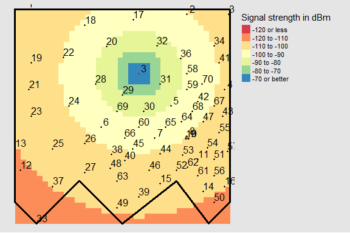

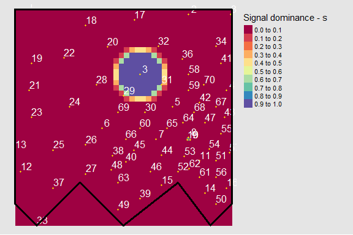

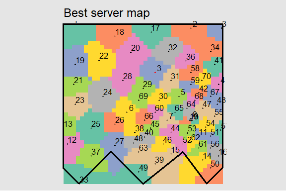

```r
map_sig_strength(rst,
                 dt = strength,
                 cp = cp,
                 region = region,
                 cells = 3,
                 type = "dBm",
                 interactive = FALSE,
                 settings = mobvis_settings(cell_size = 1,
                                            cell_labels = TRUE))
map_sig_strength(rst,
                 dt = strength,
                 cp = cp,
                 region = region,
                 cells = 3,
                 type = "s",
                 interactive = FALSE,
                 settings = mobvis_settings(cell_colors = "gold",
                                            cell_size = 1,
                                            cell_labels = TRUE,
                                            cell_label_color = "white"))
map_best_server(rst = rst,
                dt = strength,
                cp = cp,
                region = region,
                cells = 3,
                type = "bsm",
                interactive = FALSE,
                settings = mobvis_settings(cell_size = 1,
                                           cell_labels = TRUE))
```

The last map, the Best Server Map shows the cell with the best signal strength per tile. Often, this is the nearest cell, but not necessarily.

## Event location

The function `map_pag` visualizes the event location. The event location (likelihood) probabilities are calculated with **mobloc** (see other vignette).

```r
library(mobloc)
param <- mobloc_param()
strength[, dist:= NA]
strength_llh <- create_strength_llh(strength, param = param)
print(strength_llh)
```

```
#>       cell  rid dist          pag
#>    1:   70  834   NA 0.0008588105
#>    2:   68  834   NA 0.1285867982
#>    3:   67  834   NA 0.1285172165
#>    4:   64  834   NA 0.0878778676
#>    5:   59  834   NA 0.0024428703
#>   ---
#> 8291:    1 1560   NA 1.0000000000
#> 8292:    1 1561   NA 1.0000000000
#> 8293:    1 1562   NA 1.0000000000
#> 8294:    1 1563   NA 1.0000000000
#> 8295:    1 1564   NA 1.0000000000
```

The **mobloc** requires the signal strength object strength with an additional column `dist`, which stands for distance between tile center and cell location. However, since we do not use `dist` for viusalization purposes, we set it to `NA`. The `data.table` object `strength_llh` has four columns cell id number `cell`, tile number `rid`, distance `dist` (not used), and event location (likelihood) probability `pag`.

In the next code chunk, we set the **mobvis** parameters, and create the map in the same way as before.

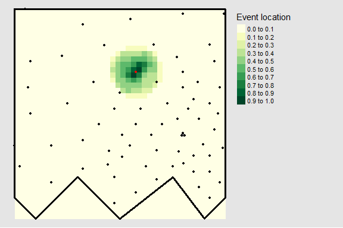

```r
# Retrieve and change the visualization settings
settings = mobvis_settings(cell_size = 2, dev_size = 2)
settings$titles["pag"] <- "Event location"

# Create the plot
map_pag(rst,
        dt = strength_llh,
        cp = cp,
        region = region,
        cells = 3,
        interactive = FALSE,
        settings = settings)
```

## Posterior probabilities

The following function visualizes the probability location. The probabilities are also calculated with **mobloc**. The network prior is used.

```r
# Calculate the event location (likelihood) probabilities using mobloc
network_prior <- create_network_prior(strength, rst)
posterior <- calculate_posterior(prior = network_prior, llh = strength_llh, raster = rst)
print(posterior)
```

```
#>       cell  rid          pga
#>    1:   70  834 0.0001291534
#>    2:   70  835 0.0001168515
#>    3:   70  871 0.0001055452
#>    4:   70  872 0.0004874089
#>    5:   70  873 0.0015114832
#>   ---
#> 8291:    1 1560 0.0376633215
#> 8292:    1 1561 0.0376842272
#> 8293:    1 1562 0.0377005947
#> 8294:    1 1563 0.0377261376
#> 8295:    1 1564 0.0375441545
```

The `data.table` object `posterior` has three columns, cell id `cell, tile number`rid`, and posterior probability`pga`.

The map is created as follows:

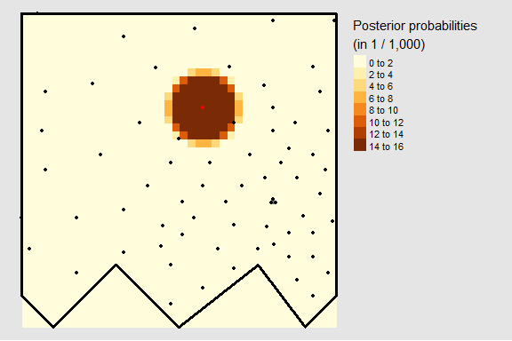

```r
# Edit settings
settings$titles["pga"] <- "Posterior probabilities"

# Create the plot
map_pga(rst,
        dt = posterior,
        cp = cp,
        region = region,
        cells = 3,
        interactive = FALSE,
        settings = settings)
```

## Trajectories

The simulator simulates trajectories of devices. The following code retrieves the routes and calculates the traveled distance per device.

```r
# get route and distance per device
(routes <- sim_get_trajectory_routes(sim))
```

```
#> Simple feature collection with 218 features and 2 fields
#> geometry type:  LINESTRING
#> dimension:      XY
#> bbox:           xmin: 0.222278 ymin: 173.5552 xmax: 9968.539 ymax: 9999.14
#> CRS:            NA
#> First 10 features:
#>    dev                       geometry   distance
#> 1  715 LINESTRING (4017.366 7033.9...     0.0000
#> 2  296 LINESTRING (9327.627 3230.0...  2231.8886
#> 3  235 LINESTRING (2194.794 3325.6... 10126.7878
#> 4  151 LINESTRING (7826.635 2489.3...  1971.6423
#> 5  534 LINESTRING (9822.37 1066.85...  2174.5527
#> 6  155 LINESTRING (5277.111 1260.1...  1934.5656
#> 7  114 LINESTRING (1407.183 7679.4...     0.0000
#> 8  451 LINESTRING (1761.867 3206.8...   413.1809
#> 9  137 LINESTRING (3406.703 7232.9...  9183.9660
#> 10 520 LINESTRING (2818.848 2529.3... 12029.7840
```

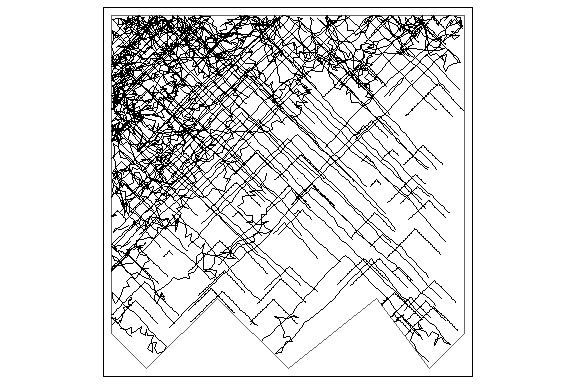

```r
# plot the routes with tmap (run tmap_mode("view") to show it interactively)
qtm(region, fill= NULL) + qtm(routes)
```

The following code chunk creates an animation of the event locations of the cells to which device 250 is connected. Both gif and mp4 animations can be created. The former generally creates sharper images, but is much larger in file size.

```r
traj <- sim_get_trajectory_data(sim, device = 250)

settings = mobvis_settings_animation(cell_size = 2, dev_size = 2)

animate_pag(rst = rst,
            dt = strength_llh,
            cp = cp,
            traj = traj,
            region = region,
            settings = settings,
            title = "Event location at time %s",
            filename = "event_locations_dev_%s.mp4")
```

The `%s` in the title and filename are placements for the time and device id respectively. In this case `event_locations_dev_250.mp4` will be generated.

In a similar way, an animation for the posterior probabilities is created as follows.

```r
animate_pga(rst = rst,
            dt = posterior,
            cp = cp,
            traj = traj,
            region = region,
            settings = settings,
            title = "Posterior distribution at time %s",
            filename = "posterior_dev_%s.mp4")
```

## HMM probabilities

```r
prob <- sim_get_prob(sim, device = 250)

animate_p(rst = rst,
          dt = prob,
          cp = cp,
          traj = traj,
          region = region,
          settings = settings,
          title = "HMM probability distribution at time %s",
          filename = "HMM_probabilities_dev_%s.mp4")
```

## References

1. To do: add reference simulator documentation
2. Tennekes M (2018). “tmap: Thematic Maps in R.” *Journal of Statistical Software*, *84*(6), 1-39. doi: 10.18637/jss.v084.i06 (URL: https://doi.org/10.18637/jss.v084.i06).